# Variables aleatorias

Variables aleatorias

Definición • Tipos de v. a. • Función de distribución

Pablo Ortiz (@pabort)  
Estadística III (FCE-UNC)

En la clase de hoy …

En la clase de hoy …

**Definición de variables aleatorias**

**Función de distribución**

**Tipos de variables aleatorias**

## ¿Qué es una variable aleatoria?

- Está definida sobre un espacio de probabilidad $(\Omega, \mathscr{F}, P)$
- Definimos una función $X: \Omega \rightarrow \mathbb{R}$
- $X$ será v. a. si $[X \leq x] \in \mathscr{F}$, $\forall \,x \in \mathbb{R}$.

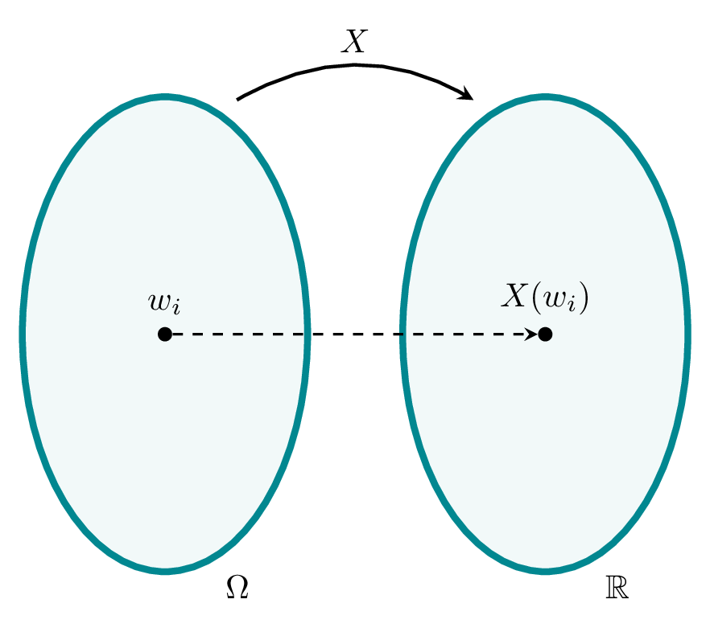

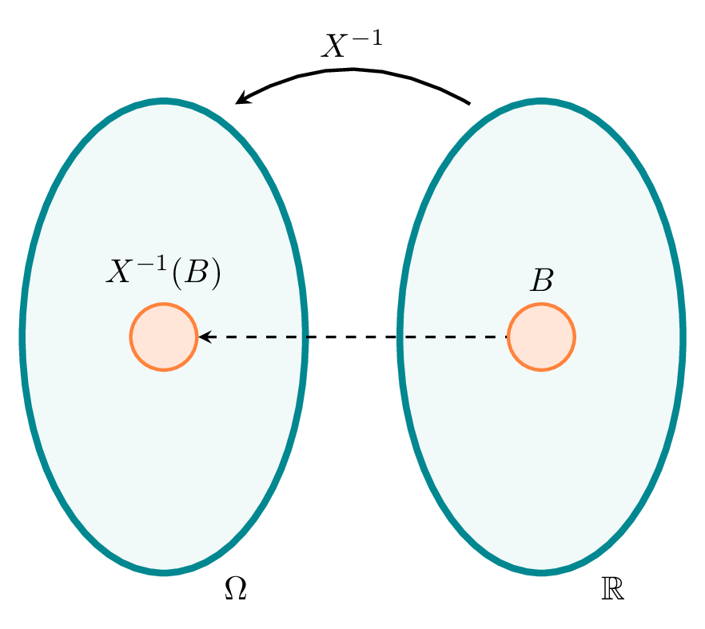

## 🔖️ Implicancias de trabajar con variables aleatorias

✅ Pasaremos de espacio medible  
$(\Omega, \mathscr{F})$ al $(\mathbb{R}, \mathscr{B}(\mathbb{R}))$

✅ Será posible trasladar la medida de probabilidad  
$P$ al espacio medible $(\mathbb{R}, \mathscr{B}(\mathbb{R}))$

$P_X(B) \equiv P(X^{-1}(B))$

✅ El espacio de probabilidad  
$(\Omega, \mathscr{F}, P)$ será ahora $(\mathbb{R}, \mathscr{B}(\mathbb{R}), P_X)$

## Función de distribución

Sea $X$ una v.a. sobre $(\Omega, \mathscr{F}, P)$, la función de distribucion de $X$ ($F_X$) se define como

$$F_X(x) \equiv P_X((-\infty, x]) \equiv P(X^{-1}(-\infty, x])$$

**📌 Observaciones**:

👉️ La función de distribución queda definida por la medida de probabilidad inducida por $X$. Entonces, $F_X(X): \mathbb{R} \rightarrow [0,1]$

👉 La función de distribución caracteriza la distribución de la v.a. $X$.

👉 En general, a efectos de simplificar la notación, la notación usada será $F(x)$.

**Propiedades de la función de distribución**

1️⃣ Es monónotona no decreciente: Si $x_1 \leq x_2 \, \Rightarrow \, F(x_1) \leq F(x_2)$

2️⃣ $\lim_{x \rightarrow +\infty} F(x) = 1$

3️⃣ $\lim_{x \rightarrow -\infty} F(x) = 0$

4️⃣ Continua por derecha: $\lim_{x \rightarrow x_{0}^{+}} = F(x_{0})$

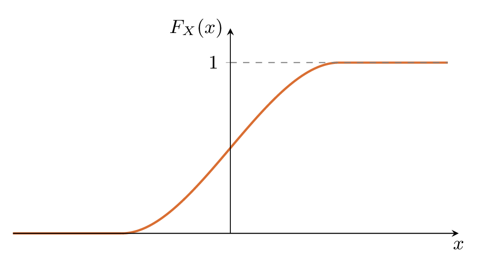

## Variables aleatorias discretas

$X$ es una v.a. discreta si puede asumir un número finito o numerable de valores ${x_1 , x_2 , \dots } \subset \mathbb{R}$.

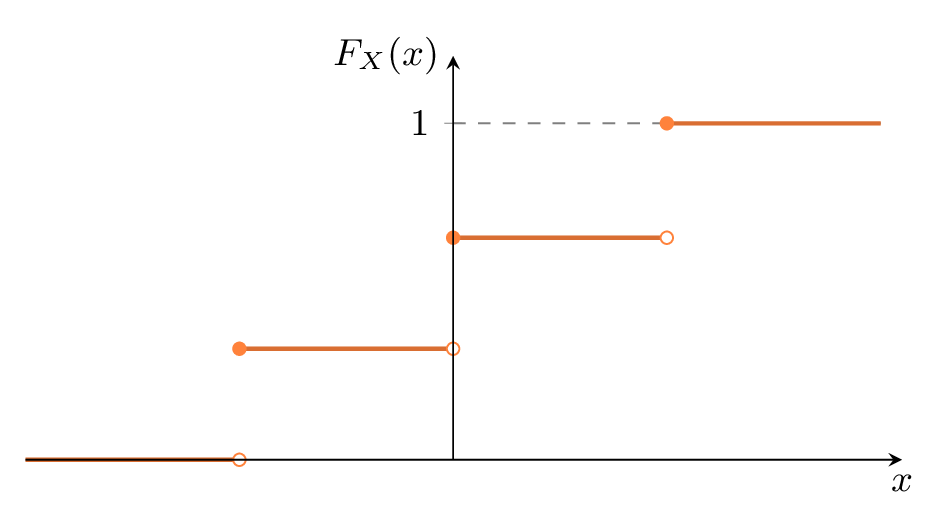

👉 **Función de probabilidad**

$$p(x_i) = P(X=x_i) \mbox{ para } i=1, 2, \dots$$

👉 **Función de distribución**

$$F_X(x) = \sum_{i: \, x_i \leq x} P(X=x_i) = \sum_{i:\, x_i \leq x} p(x_i)$$

👉 **Cálculo de probabilidades**

$$P(X \in B)= P_X(B) = P_X(B \cap R_X) = \sum_{x \in (B \cap R_X)} p(x)$$
$R_X$ representa el rango de la v.a. $X$ (los valores que puede asumir $X$ con probabilidad estrictamente positiva).

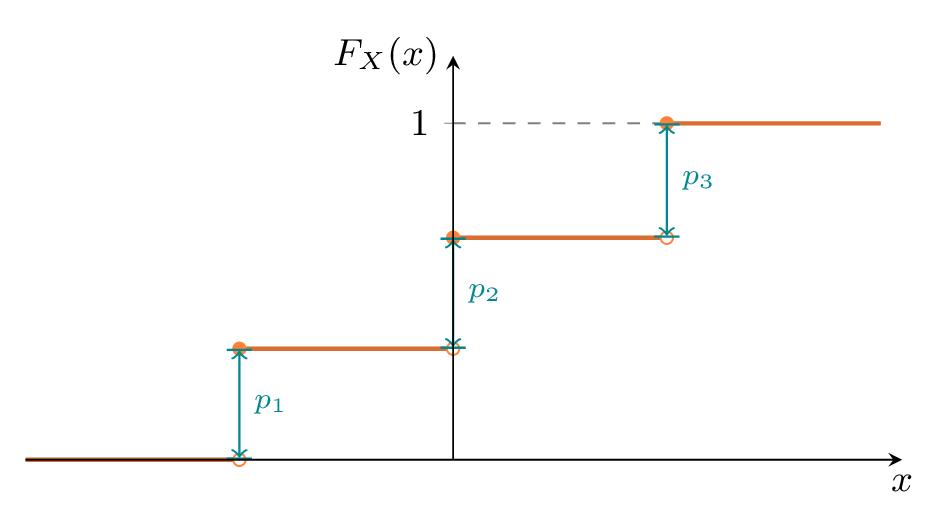

## Variables aleatorias (absolutamente) continuas

$X$ es una v.a. (absolutamente) continua si existe una función $f(x)$ no negativa e integrable tal que para todo $x$ se cumple que $F_X(x) = \int_{-\infty}^{x} f(u) \,du$

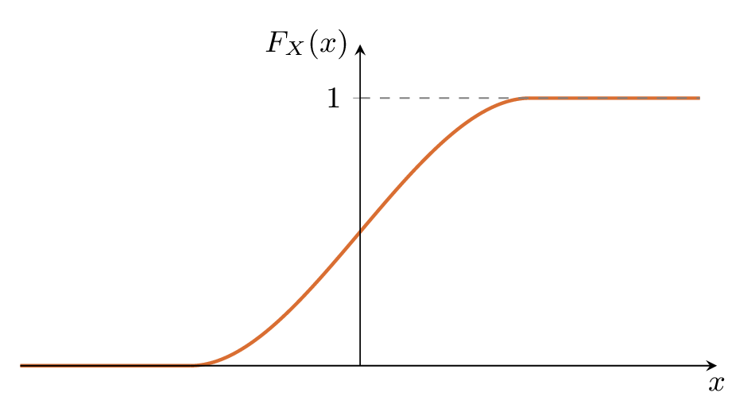

👉 $f(x)$ se denomina función de densidad de $X$.

👉 Una función $f(x)$ es densidad de alguna v.a. $X$ sii:
$$\int_{-\infty}^{+\infty} f(x) \,dx = 1$$

👉 Cálculo de probabilidades
$$P(X \in B)= P_X(B) = \int_{B} f(x) \,dx \quad \forall \, B \in \mathscr{B}$$

## Variables aleatorias mixtas

$X$ es una v.a. mixta si no es ni (absolutamente continua) ni discreta; pero si una combinación de los dos tipos.

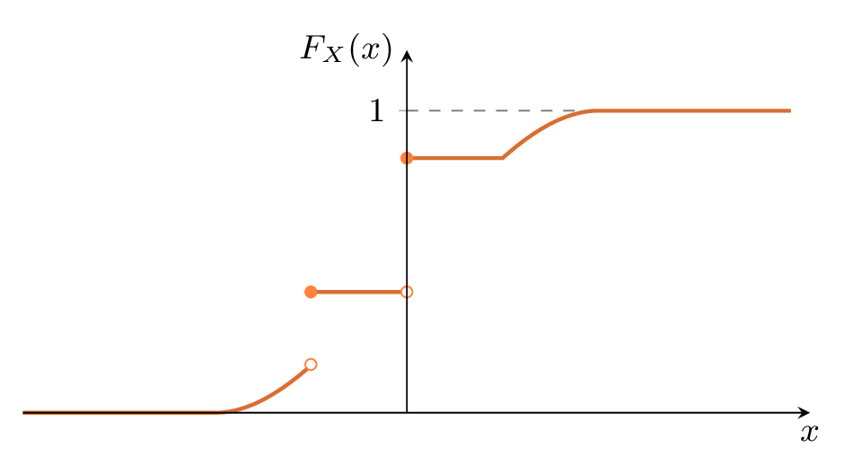

**Descomposición**: $F_X(x) = F_d + F_{ac}$

👉 **Parte discreta** Sea $J = \{x_1 , x_2 , \dots\}$ el conjunto de puntos de salto de $F$, se representa el valor del salto de $F$ en $x_i \in J$ como:
$$p_i(x_i) = F(x_i) - F(x_i^{-})$$

$$F_d(x) = \sum_{i_\, x_i \leq x} p(x_i)$$

👉 **Parte absolutamente continua**

$$f(x) = \left \{
\begin{array}{ll}
\ F'(x) & \mbox{si $F$ es diferenciable en $x$}\\
\ 0 & \mbox{caso contrario},
\end{array}
\right.$$

$$F_{ac}(x) = \int_{-\infty}^{+\infty} f(u) \,dt$$

Pablo Ortiz | pabort@eco.uncor.edu | Estadística III